# Project1-Markdown

### Divisive clustering - DIANA, Ward linkage.

```r
library(fpc)
PG_clust_diana <- eclust(scaled_PG, k=2, FUNcluster = 'diana', hc_method = 'ward.D')
```

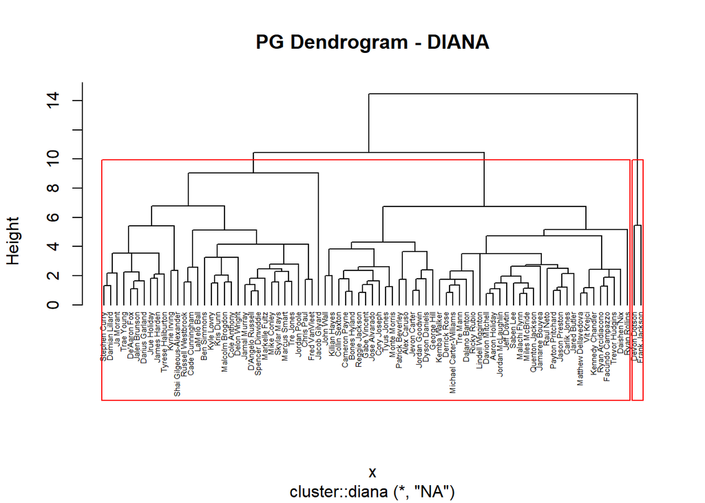

```r
pltree(PG_clust_diana, hang = -1, main = "PG Dendrogram - DIANA", cex = 0.47)
rect.hclust(PG_clust_diana, k=2, border='red')
```

```r
diana_stats_PG <- cluster.stats(dist(scaled_PG), PG_clust_diana$cluster)
diana_stats_PG$avg.silwidth
```

```
## [1] 0.5365441
```

```r
diana_stats_PG$cluster.size
```

```
## [1] 79  2
```

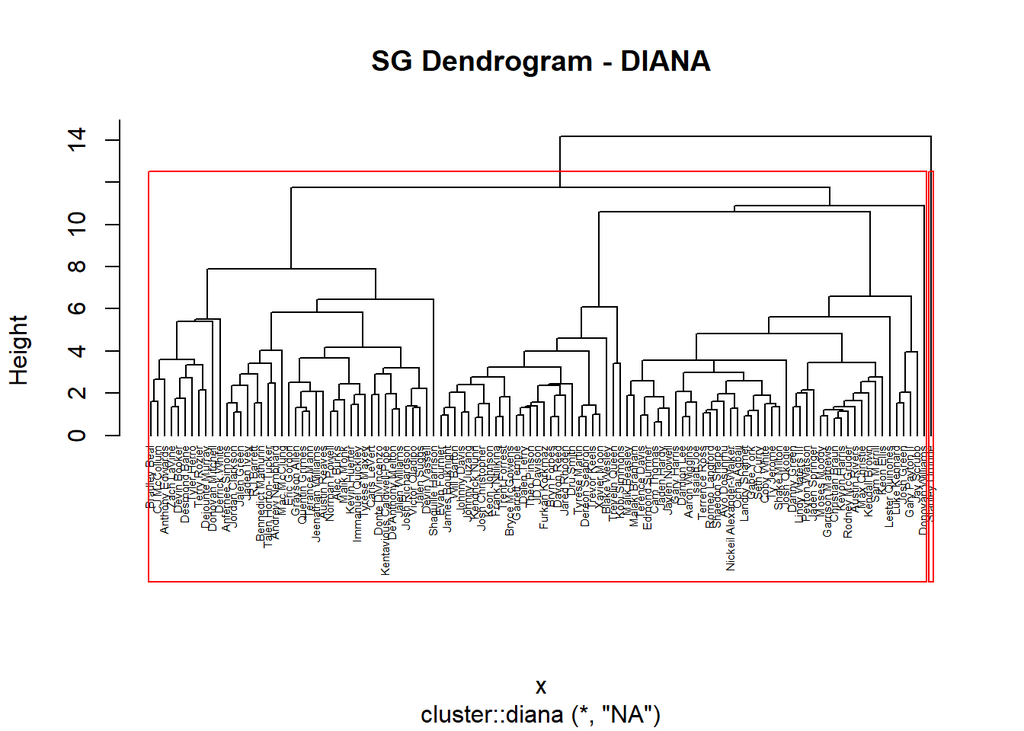

```r
SG_clust_diana <- eclust(scaled_SG, k=2, FUNcluster = 'diana', hc_method = 'ward.D')
pltree(SG_clust_diana, hang = -1, main = "SG Dendrogram - DIANA", cex = 0.47)
rect.hclust(SG_clust_diana, k=2, border='red')
```

```r
diana_stats_SG <- cluster.stats(dist(scaled_SG), SG_clust_diana$cluster)
diana_stats_SG$avg.silwidth
```

```
## [1] 0.6348855
```

```r
diana_stats_SG$cluster.size
```

```
## [1] 113   1
```

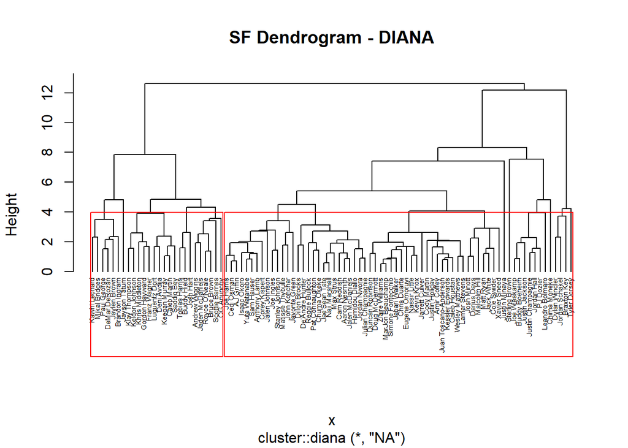

```r
SF_clust_diana <- eclust(scaled_SF, k=2, FUNcluster = 'diana', hc_method = 'ward.D')
pltree(SF_clust_diana, hang = -1, main = "SF Dendrogram - DIANA", cex = 0.47)
rect.hclust(SF_clust_diana, k=2, border='red')
```

```r
diana_stats_SF <- cluster.stats(dist(scaled_SF), SF_clust_diana$cluster)
diana_stats_SF$avg.silwidth
```

```
## [1] 0.3440443
```

```r
diana_stats_SF$cluster.size
```

```
## [1] 26 68
```

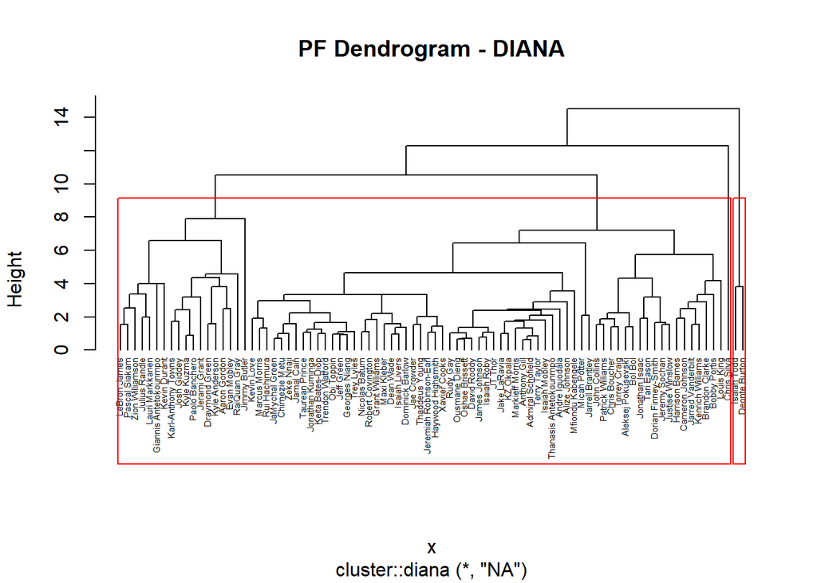

```r
PF_clust_diana <- eclust(scaled_PF, k=2, FUNcluster = 'diana', hc_method = 'ward.D')
pltree(PF_clust_diana, hang = -1, main = "PF Dendrogram - DIANA", cex = 0.47)
rect.hclust(PF_clust_diana, k=2, border='red')
```

```r
diana_stats_PF <- cluster.stats(dist(scaled_PF), PF_clust_diana$cluster)
diana_stats_PF$avg.silwidth
```

```
## [1] 0.5308374
```

```r
diana_stats_PF$cluster.size
```

```
## [1] 84  2
```

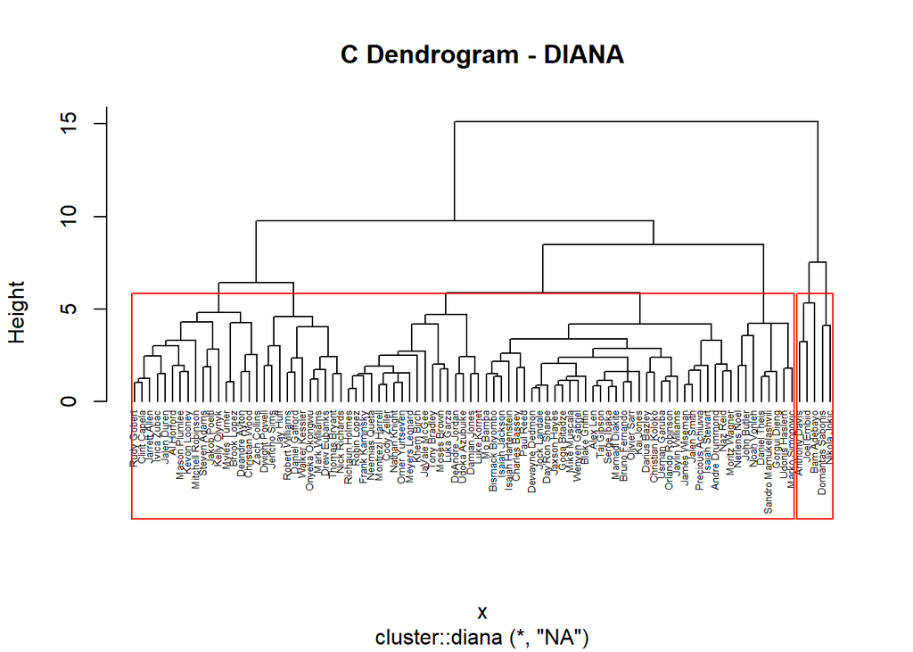

```r
C_clust_diana <- eclust(scaled_C, k=2, FUNcluster = 'diana', hc_method = 'ward.D')
pltree(C_clust_diana, hang = -1, main = "C Dendrogram - DIANA", cex = 0.47)
rect.hclust(C_clust_diana, k=2, border='red')
```

```r
diana_stats_C <- cluster.stats(dist(scaled_C), C_clust_diana$cluster)
diana_stats_C$avg.silwidth
```

```
## [1] 0.5365329
```

```r
diana_stats_C$cluster.size
```

```
## [1] 87  5
```

### Agglomerative clustering - AGNES, Ward linkage.

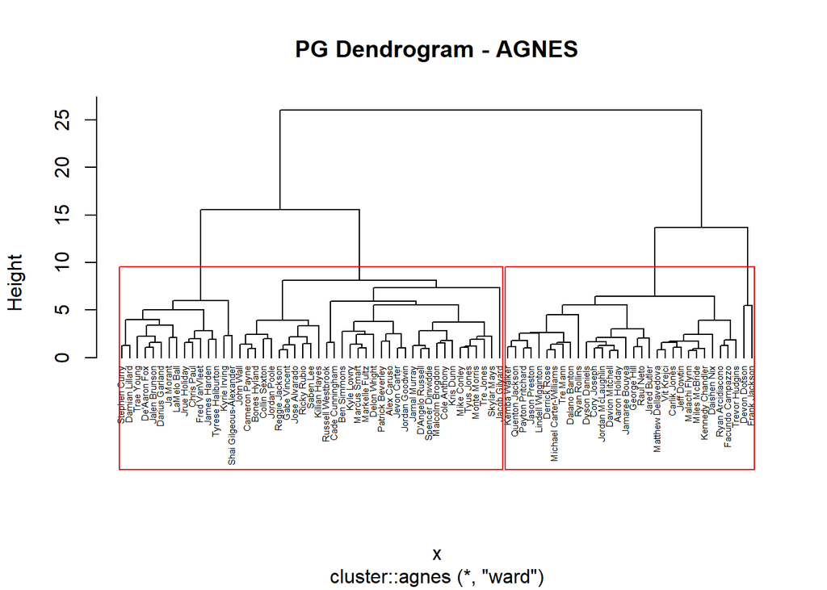

```r
PG_clust_agnes <- eclust(scaled_PG, k=2, FUNcluster = 'agnes', hc_method = 'ward.D')
pltree(PG_clust_agnes, hang = -1, main = "PG Dendrogram - AGNES", cex = 0.47)
rect.hclust(PG_clust_agnes, k=2, border='red')
```

```r
agnes_stats_PG <- cluster.stats(dist(scaled_PG), PG_clust_agnes$cluster)
agnes_stats_PG$avg.silwidth
```

```
## [1] 0.3250184
```

```r
agnes_stats_PG$cluster.size
```

```
## [1] 49 32
```

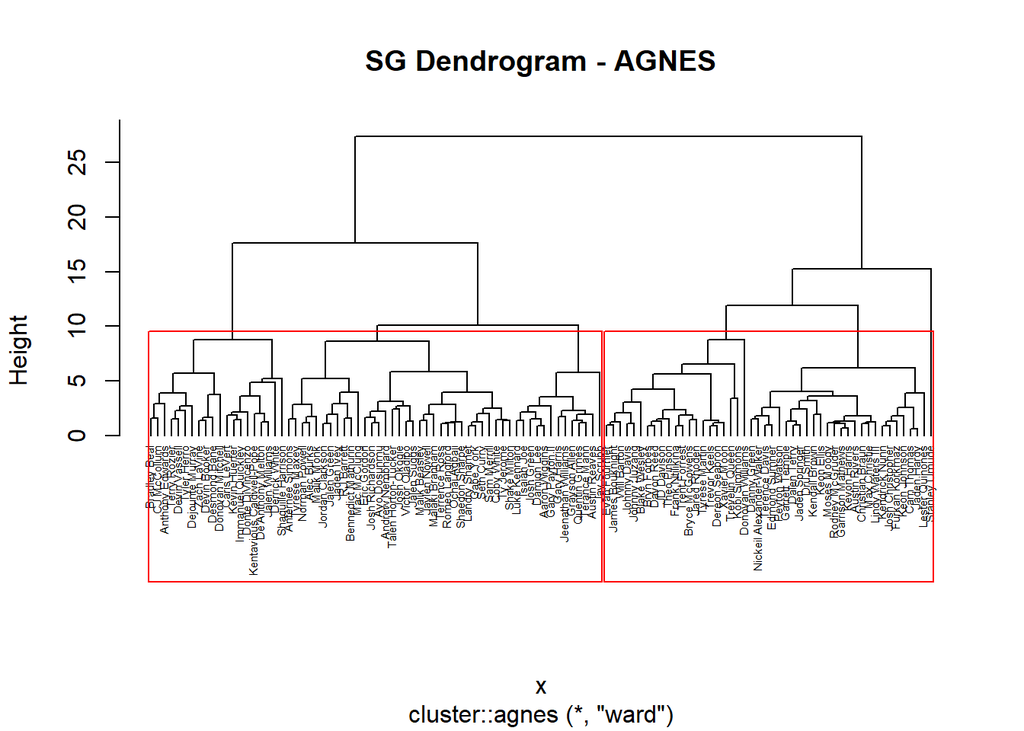

```r
SG_clust_agnes <- eclust(scaled_SG, k=2, FUNcluster = 'agnes', hc_method = 'ward.D')
pltree(SG_clust_agnes, hang = -1, main = "SG Dendrogram - AGNES", cex = 0.47)
rect.hclust(SG_clust_agnes, k=2, border='red')
```

```r
agnes_stats_SG <- cluster.stats(dist(scaled_SG), SG_clust_agnes$cluster)
agnes_stats_SG$avg.silwidth
```

```
## [1] 0.2648314
```

```r
agnes_stats_SG$cluster.size
```

```
## [1] 66 48
```

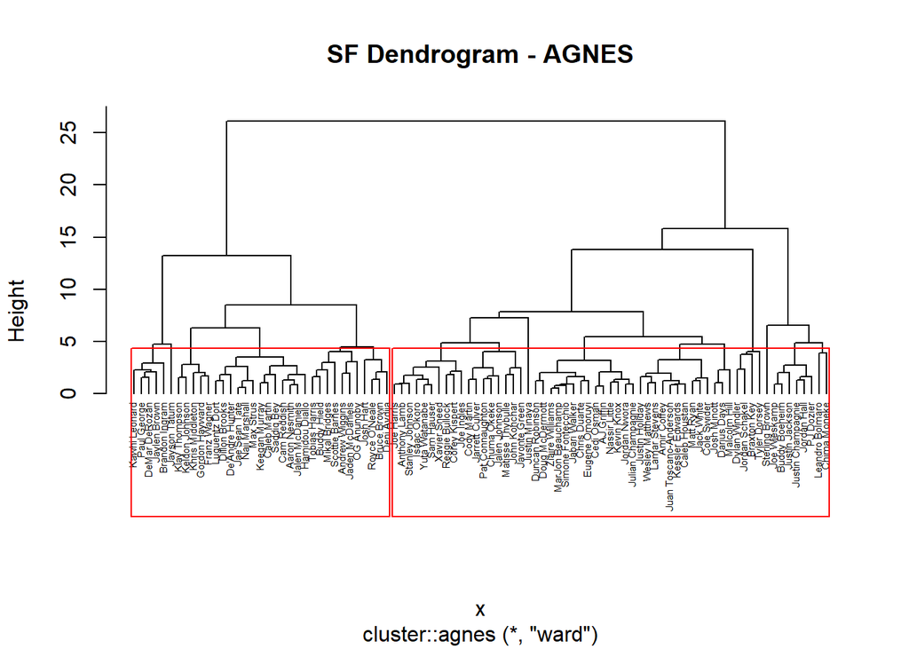

```r
SF_clust_agnes <- eclust(scaled_SF, k=2, FUNcluster = 'agnes', hc_method = 'ward.D')
pltree(SF_clust_agnes, hang = -1, main = "SF Dendrogram - AGNES", cex = 0.47)
rect.hclust(SF_clust_agnes, k=2, border='red')
```

```r
agnes_stats_SF <- cluster.stats(dist(scaled_SF), SF_clust_agnes$cluster)
agnes_stats_SF$avg.silwidth
```

```
## [1] 0.296468
```

```r
agnes_stats_SF$cluster.size
```

```
## [1] 35 59
```

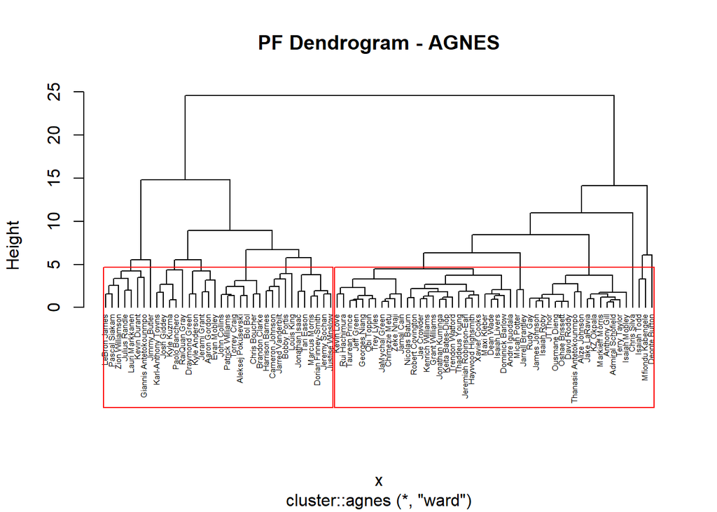

```r
PF_clust_agnes <- eclust(scaled_PF, k=2, FUNcluster = 'agnes', hc_method = 'ward.D')
pltree(PF_clust_agnes, hang = -1, main = "PF Dendrogram - AGNES", cex = 0.47)
rect.hclust(PF_clust_agnes, k=2, border='red')
```

```r
agnes_stats_PF <- cluster.stats(dist(scaled_PF), PF_clust_agnes$cluster)
agnes_stats_PF$avg.silwidth
```

```
## [1] 0.3015836
```

```r
agnes_stats_PF$cluster.size
```

```
## [1] 36 50
```

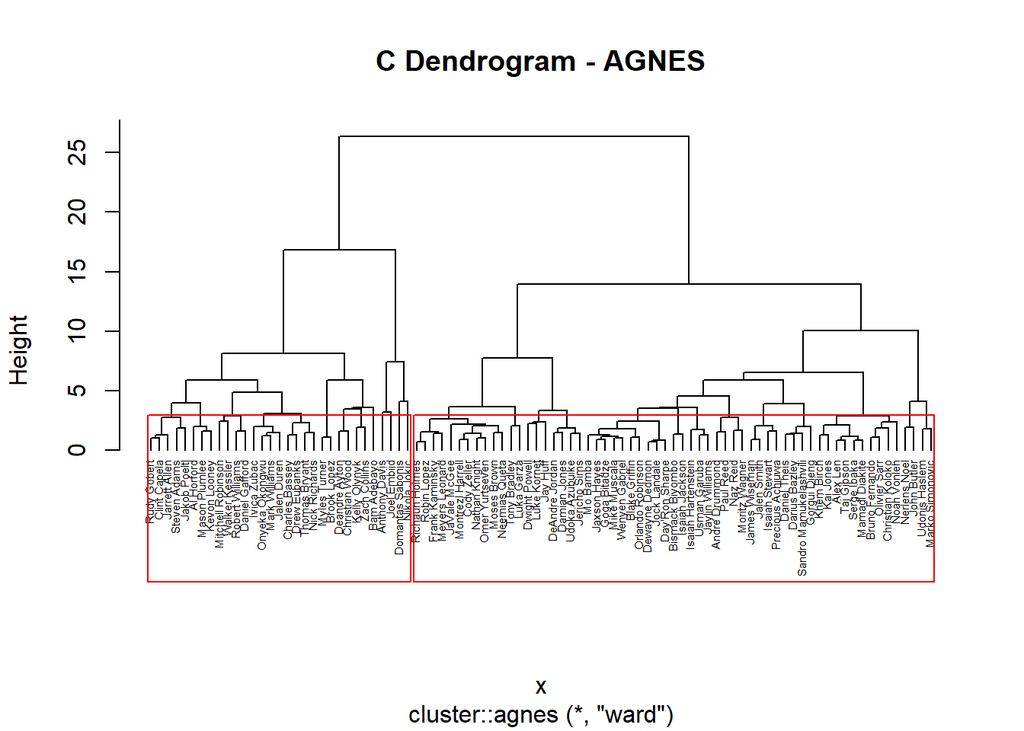

```r
C_clust_agnes <- eclust(scaled_C, k=2, FUNcluster = 'agnes', hc_method = 'ward.D')
pltree(C_clust_agnes, hang = -1, main = "C Dendrogram - AGNES", cex = 0.47)
rect.hclust(C_clust_agnes, k=2, border='red')
```

```r
agnes_stats_C <- cluster.stats(dist(scaled_C), C_clust_agnes$cluster)
agnes_stats_C$avg.silwidth
```

```
## [1] 0.3328099
```

```r
agnes_stats_C$cluster.size
```

```
## [1] 31 61
```

The results show that divisive clustering algorithm got a bit ‘lost’ during division of the data to clusters. There are mostly clusters which contain almost every player from the data-set in one cluster and just a few in the other cluster. Such results do not give us any insights into the data.

On the other hand the result for agglomerative approach are a bit closer to the expected outcome, with the contents of clusters representing quite visible division into “positive/negative impact” players, nevertheless the silhouette width values are lower than for the PAM algorithm, therefore the final analysis will be conducted on the results of the PAM clustering.

## Data analysis within clusters.

```r
stats_PG['cluster_label'] = PG_clust_pam$clustering
stats_SG['cluster_label'] = SG_clust_pam$clustering
stats_SF['cluster_label'] = SF_clust_pam$clustering
stats_PF['cluster_label'] = PF_clust_pam$clustering
stats_C['cluster_label'] = C_clust_pam$clustering
```

### Comparison of statistics inside of clusters.

```r
summary(stats_PG[stats_PG$cluster_label == 1,2:12]) %>% kbl() %>% kable_paper("hover")
```

|  | MP | PTS | AST | STL | BLK | TRB | eFG. | TS. | USG. | WS.48 | VORP |
| --- | --- | --- | --- | --- | --- | --- | --- | --- | --- | --- | --- |
|  | Min. :22.20 | Min. : 3.00 | Min. : 2.900 | Min. :0.600 | Min. :0.00 | Min. :2.200 | Min. :0.4260 | Min. :0.4550 | Min. : 5.10 | Min. :-0.0180 | Min. :-1.000 |
|  | 1st Qu.:27.25 | 1st Qu.:11.47 | 1st Qu.: 5.275 | 1st Qu.:0.900 | 1st Qu.:0.20 | 1st Qu.:3.075 | 1st Qu.:0.5108 | 1st Qu.:0.5447 | 1st Qu.:18.85 | 1st Qu.: 0.0950 | 1st Qu.: 0.575 |
|  | Median :31.95 | Median :15.60 | Median : 6.200 | Median :1.100 | Median :0.40 | Median :3.950 | Median :0.5350 | Median :0.5730 | Median :23.00 | Median : 0.1215 | Median : 1.600 |
|  | Mean :31.09 | Mean :16.89 | Mean : 6.310 | Mean :1.167 | Mean :0.37 | Mean :4.080 | Mean :0.5303 | Mean :0.5722 | Mean :22.89 | Mean : 0.1205 | Mean : 1.863 |
|  | 3rd Qu.:34.73 | 3rd Qu.:21.15 | 3rd Qu.: 7.325 | 3rd Qu.:1.325 | 3rd Qu.:0.50 | 3rd Qu.:4.800 | 3rd Qu.:0.5573 | 3rd Qu.:0.6052 | 3rd Qu.:28.00 | 3rd Qu.: 0.1568 | 3rd Qu.: 2.825 |
|  | Max. :41.00 | Max. :32.20 | Max. :10.700 | Max. :3.000 | Max. :1.00 | Max. :6.400 | Max. :0.6140 | Max. :0.6560 | Max. :34.90 | Max. : 0.2260 | Max. : 5.600 |

```r
summary(stats_PG[stats_PG$cluster_label == 2,2:12]) %>% kbl() %>% kable_paper("hover")
```

|  | MP | PTS | AST | STL | BLK | TRB | eFG. | TS. | USG. | WS.48 | VORP |
| --- | --- | --- | --- | --- | --- | --- | --- | --- | --- | --- | --- |
|  | Min. : 5.00 | Min. : 0.000 | Min. :0.50 | Min. :0.0000 | Min. :0.0000 | Min. :0.000 | Min. :0.0000 | Min. :0.0000 | Min. :10.70 | Min. :-0.37800 | Min. :-1.00000 |
|  | 1st Qu.: 8.90 | 1st Qu.: 2.900 | 1st Qu.:1.20 | 1st Qu.:0.3000 | 1st Qu.:0.0000 | 1st Qu.:1.000 | 1st Qu.:0.4430 | 1st Qu.:0.4750 | 1st Qu.:13.40 | 1st Qu.: 0.01800 | 1st Qu.:-0.10000 |
|  | Median :13.40 | Median : 4.600 | Median :1.70 | Median :0.5000 | Median :0.1000 | Median :1.500 | Median :0.4820 | Median :0.5080 | Median :17.30 | Median : 0.04700 | Median : 0.00000 |
|  | Mean :13.64 | Mean : 4.854 | Mean :1.91 | Mean :0.5024 | Mean :0.1366 | Mean :1.505 | Mean :0.4588 | Mean :0.4861 | Mean :17.42 | Mean : 0.02798 | Mean :-0.05122 |
|  | 3rd Qu.:17.70 | 3rd Qu.: 6.600 | 3rd Qu.:2.40 | 3rd Qu.:0.7000 | 3rd Qu.:0.2000 | 3rd Qu.:2.000 | 3rd Qu.:0.5020 | 3rd Qu.:0.5360 | 3rd Qu.:20.60 | 3rd Qu.: 0.07000 | 3rd Qu.: 0.10000 |
|  | Max. :25.90 | Max. :11.800 | Max. :4.50 | Max. :1.1000 | Max. :0.4000 | Max. :3.300 | Max. :0.5780 | Max. :0.6280 | Max. :28.00 | Max. : 0.14200 | Max. : 0.80000 |

```r
summary(stats_SG[stats_SG$cluster_label == 1,2:12]) %>% kbl() %>% kable_paper("hover")
```

|  | MP | PTS | AST | STL | BLK | TRB | eFG. | TS. | USG. | WS.48 | VORP |
| --- | --- | --- | --- | --- | --- | --- | --- | --- | --- | --- | --- |
|  | Min. :20.20 | Min. : 8.80 | Min. :1.800 | Min. :0.400 | Min. :0.1000 | Min. :2.600 | Min. :0.4580 | Min. :0.508 | Min. :14.10 | Min. :-0.00100 | Min. :-0.700 |
|  | 1st Qu.:28.10 | 1st Qu.:12.25 | 1st Qu.:3.450 | 1st Qu.:0.800 | 1st Qu.:0.2000 | 1st Qu.:3.250 | 1st Qu.:0.5035 | 1st Qu.:0.539 | 1st Qu.:20.10 | 1st Qu.: 0.05200 | 1st Qu.: 0.400 |
|  | Median :31.30 | Median :18.50 | Median :3.900 | Median :1.000 | Median :0.3000 | Median :4.000 | Median :0.5370 | Median :0.566 | Median :25.40 | Median : 0.09100 | Median : 1.300 |
|  | Mean :30.83 | Mean :17.45 | Mean :4.016 | Mean :1.061 | Mean :0.3548 | Mean :3.968 | Mean :0.5305 | Mean :0.568 | Mean :23.86 | Mean : 0.08829 | Mean : 1.268 |
|  | 3rd Qu.:34.75 | 3rd Qu.:21.10 | 3rd Qu.:4.400 | 3rd Qu.:1.350 | 3rd Qu.:0.4500 | 3rd Qu.:4.500 | 3rd Qu.:0.5595 | 3rd Qu.:0.601 | 3rd Qu.:26.65 | 3rd Qu.: 0.12100 | 3rd Qu.: 2.000 |
|  | Max. :36.40 | Max. :28.30 | Max. :6.100 | Max. :2.200 | Max. :0.9000 | Max. :5.800 | Max. :0.6030 | Max. :0.617 | Max. :32.10 | Max. : 0.17600 | Max. : 5.000 |

```r
summary(stats_SG[stats_SG$cluster_label == 2,2:12]) %>% kbl() %>% kable_paper("hover")
```

|  | MP | PTS | AST | STL | BLK | TRB | eFG. | TS. | USG. | WS.48 | VORP |
| --- | --- | --- | --- | --- | --- | --- | --- | --- | --- | --- | --- |
|  | Min. : 2.0 | Min. : 0.800 | Min. :0.000 | Min. :0.0000 | Min. :0.0000 | Min. :0.000 | Min. :0.0000 | Min. :0.3370 | Min. :10.30 | Min. :-0.22500 | Min. :-1.30000 |
|  | 1st Qu.:10.6 | 1st Qu.: 3.150 | 1st Qu.:0.650 | 1st Qu.:0.3000 | 1st Qu.:0.1000 | 1st Qu.:1.400 | 1st Qu.:0.4650 | 1st Qu.:0.5045 | 1st Qu.:14.60 | 1st Qu.: 0.01450 | 1st Qu.:-0.20000 |
|  | Median :15.1 | Median : 5.800 | Median :1.200 | Median :0.5000 | Median :0.1000 | Median :2.000 | Median :0.5220 | Median :0.5550 | Median :17.30 | Median : 0.06100 | Median : 0.00000 |
|  | Mean :15.6 | Mean : 6.282 | Mean :1.359 | Mean :0.4855 | Mean :0.1807 | Mean :2.013 | Mean :0.5103 | Mean :0.5438 | Mean :18.15 | Mean : 0.05559 | Mean :-0.03855 |
|  | 3rd Qu.:20.5 | 3rd Qu.: 8.800 | 3rd Qu.:1.700 | 3rd Qu.:0.7000 | 3rd Qu.:0.2500 | 3rd Qu.:2.700 | 3rd Qu.:0.5550 | 3rd Qu.:0.5900 | 3rd Qu.:19.55 | 3rd Qu.: 0.09450 | 3rd Qu.: 0.10000 |
|  | Max. :29.9 | Max. :16.700 | Max. :4.500 | Max. :1.1000 | Max. :1.0000 | Max. :5.000 | Max. :0.8570 | Max. :0.8250 | Max. :52.50 | Max. : 0.62600 | Max. : 1.20000 |

```r
summary(stats_SF[stats_SF$cluster_label == 1,2:12]) %>% kbl() %>% kable_paper("hover")
```

|  | MP | PTS | AST | STL | BLK | TRB | eFG. | TS. | USG. | WS.48 | VORP |
| --- | --- | --- | --- | --- | --- | --- | --- | --- | --- | --- | --- |
|  | Min. :20.80 | Min. : 5.10 | Min. :1.200 | Min. :0.700 | Min. :0.200 | Min. :3.900 | Min. :0.4660 | Min. :0.5130 | Min. :10.40 | Min. :0.03000 | Min. :-0.600 |
|  | 1st Qu.:30.20 | 1st Qu.:12.15 | 1st Qu.:2.200 | 1st Qu.:0.900 | 1st Qu.:0.300 | 1st Qu.:4.350 | 1st Qu.:0.5210 | 1st Qu.:0.5570 | 1st Qu.:17.25 | 1st Qu.:0.08550 | 1st Qu.: 0.500 |
|  | Median :32.30 | Median :15.30 | Median :3.300 | Median :1.000 | Median :0.400 | Median :5.000 | Median :0.5400 | Median :0.5810 | Median :20.30 | Median :0.09100 | Median : 1.000 |
|  | Mean :31.69 | Mean :16.76 | Mean :3.219 | Mean :1.037 | Mean :0.463 | Mean :5.263 | Mean :0.5390 | Mean :0.5757 | Mean :21.64 | Mean :0.09856 | Mean : 1.356 |
|  | 3rd Qu.:34.40 | 3rd Qu.:21.95 | 3rd Qu.:4.000 | 3rd Qu.:1.100 | 3rd Qu.:0.600 | 3rd Qu.:5.900 | 3rd Qu.:0.5565 | 3rd Qu.:0.5945 | 3rd Qu.:27.20 | 3rd Qu.:0.11500 | 3rd Qu.: 1.900 |
|  | Max. :36.90 | Max. :30.10 | Max. :5.800 | Max. :1.900 | Max. :1.000 | Max. :8.800 | Max. :0.5960 | Max. :0.6230 | Max. :32.70 | Max. :0.19400 | Max. : 5.100 |

```r
summary(stats_SF[stats_SF$cluster_label == 2,2:12]) %>% kbl() %>% kable_paper("hover")
```

|  | MP | PTS | AST | STL | BLK | TRB | eFG. | TS. | USG. | WS.48 | VORP |
| --- | --- | --- | --- | --- | --- | --- | --- | --- | --- | --- | --- |
|  | Min. : 1.80 | Min. : 0.00 | Min. :0.000 | Min. :0.0000 | Min. :0.0000 | Min. :0.000 | Min. :0.0000 | Min. :0.0000 | Min. : 7.00 | Min. :-0.28800 | Min. :-1.1000 |
|  | 1st Qu.: 9.05 | 1st Qu.: 3.05 | 1st Qu.:0.550 | 1st Qu.:0.2000 | 1st Qu.:0.1000 | 1st Qu.:1.300 | 1st Qu.:0.4730 | 1st Qu.:0.4960 | 1st Qu.:13.15 | 1st Qu.: 0.03250 | 1st Qu.:-0.3000 |
|  | Median :15.80 | Median : 5.20 | Median :0.900 | Median :0.4000 | Median :0.2000 | Median :2.200 | Median :0.5180 | Median :0.5460 | Median :16.50 | Median : 0.05700 | Median :-0.1000 |
|  | Mean :15.14 | Mean : 5.49 | Mean :1.004 | Mean :0.4284 | Mean :0.2134 | Mean :2.263 | Mean :0.5169 | Mean :0.5371 | Mean :16.01 | Mean : 0.05542 | Mean :-0.0791 |
|  | 3rd Qu.:19.80 | 3rd Qu.: 7.60 | 3rd Qu.:1.400 | 3rd Qu.:0.6000 | 3rd Qu.:0.3000 | 3rd Qu.:3.300 | 3rd Qu.:0.5775 | 3rd Qu.:0.5915 | 3rd Qu.:18.85 | 3rd Qu.: 0.08700 | 3rd Qu.: 0.1000 |
|  | Max. :31.70 | Max. :15.40 | Max. :3.300 | Max. :1.2000 | Max. :1.3000 | Max. :4.600 | Max. :1.0000 | Max. :1.0640 | Max. :28.30 | Max. : 0.36700 | Max. : 1.0000 |

```r
summary(stats_PF[stats_PF$cluster_label == 1,2:12]) %>% kbl() %>% kable_paper("hover")
```

|  | MP | PTS | AST | STL | BLK | TRB | eFG. | TS. | USG. | WS.48 | VORP |
| --- | --- | --- | --- | --- | --- | --- | --- | --- | --- | --- | --- |
|  | Min. :26.00 | Min. : 8.50 | Min. :1.500 | Min. :0.000 | Min. :0.000 | Min. : 4.000 | Min. :0.4650 | Min. :0.5290 | Min. :13.20 | Min. :0.0190 | Min. :0.000 |
|  | 1st Qu.:31.40 | 1st Qu.:16.27 | 1st Qu.:2.950 | 1st Qu.:0.675 | 1st Qu.:0.475 | 1st Qu.: 6.675 | 1st Qu.:0.5457 | 1st Qu.:0.5795 | 1st Qu.:21.62 | 1st Qu.:0.1040 | 1st Qu.:1.150 |
|  | Median :33.60 | Median :20.65 | Median :4.700 | Median :0.800 | Median :0.600 | Median : 7.500 | Median :0.5625 | Median :0.5985 | Median :25.60 | Median :0.1400 | Median :2.000 |
|  | Mean :33.00 | Mean :20.62 | Mean :4.400 | Mean :0.810 | Mean :0.655 | Mean : 7.570 | Mean :0.5682 | Mean :0.6051 | Mean :25.32 | Mean :0.1375 | Mean :2.290 |
|  | 3rd Qu.:35.12 | 3rd Qu.:25.23 | 3rd Qu.:5.725 | 3rd Qu.:0.925 | 3rd Qu.:0.800 | 3rd Qu.: 8.700 | 3rd Qu.:0.5837 | 3rd Qu.:0.6258 | 3rd Qu.:28.30 | 3rd Qu.:0.1618 | 3rd Qu.:3.525 |
|  | Max. :37.40 | Max. :31.10 | Max. :7.000 | Max. :1.800 | Max. :1.500 | Max. :11.800 | Max. :0.7690 | Max. :0.7440 | Max. :38.80 | Max. :0.2770 | Max. :5.800 |

```r
summary(stats_PF[stats_PF$cluster_label == 2,2:12]) %>% kbl() %>% kable_paper("hover")
```

|  | MP | PTS | AST | STL | BLK | TRB | eFG. | TS. | USG. | WS.48 | VORP |
| --- | --- | --- | --- | --- | --- | --- | --- | --- | --- | --- | --- |
|  | Min. : 3.00 | Min. : 0.000 | Min. :0.000 | Min. :0.0 | Min. :0.0000 | Min. :0.000 | Min. :0.0000 | Min. :0.0000 | Min. : 8.40 | Min. :-0.34700 | Min. :-0.7000 |
|  | 1st Qu.:11.43 | 1st Qu.: 3.825 | 1st Qu.:0.625 | 1st Qu.:0.3 | 1st Qu.:0.2000 | 1st Qu.:2.400 | 1st Qu.:0.5012 | 1st Qu.:0.5210 | 1st Qu.:13.53 | 1st Qu.: 0.05025 | 1st Qu.:-0.1750 |
|  | Median :17.40 | Median : 6.100 | Median :0.950 | Median :0.5 | Median :0.3000 | Median :3.400 | Median :0.5485 | Median :0.5670 | Median :15.70 | Median : 0.08000 | Median : 0.0000 |
|  | Mean :17.15 | Mean : 6.292 | Mean :1.097 | Mean :0.5 | Mean :0.3652 | Mean :3.385 | Mean :0.5363 | Mean :0.5608 | Mean :15.67 | Mean : 0.06744 | Mean : 0.1303 |
|  | 3rd Qu.:21.85 | 3rd Qu.: 8.175 | 3rd Qu.:1.500 | 3rd Qu.:0.6 | 3rd Qu.:0.4750 | 3rd Qu.:4.350 | 3rd Qu.:0.5785 | 3rd Qu.:0.6040 | 3rd Qu.:17.68 | 3rd Qu.: 0.10825 | 3rd Qu.: 0.3750 |
|  | Max. :32.50 | Max. :15.500 | Max. :3.400 | Max. :1.3 | Max. :1.3000 | Max. :7.500 | Max. :1.0000 | Max. :1.0000 | Max. :30.10 | Max. : 0.19900 | Max. : 1.5000 |

```r
summary(stats_C[stats_C$cluster_label == 1,2:12]) %>% kbl() %>% kable_paper("hover")
```

|  | MP | PTS | AST | STL | BLK | TRB | eFG. | TS. | USG. | WS.48 | VORP |
| --- | --- | --- | --- | --- | --- | --- | --- | --- | --- | --- | --- |
|  | Min. :19.30 | Min. : 7.00 | Min. :0.400 | Min. :0.4000 | Min. :0.500 | Min. : 5.600 | Min. :0.5410 | Min. :0.5640 | Min. :10.10 | Min. :0.0740 | Min. :0.400 |
|  | 1st Qu.:24.40 | 1st Qu.: 9.15 | 1st Qu.:1.100 | 1st Qu.:0.6000 | 1st Qu.:0.800 | 1st Qu.: 7.250 | 1st Qu.:0.5945 | 1st Qu.:0.6305 | 1st Qu.:14.70 | 1st Qu.:0.1455 | 1st Qu.:1.200 |
|  | Median :27.00 | Median :12.00 | Median :1.700 | Median :0.7000 | Median :1.200 | Median : 9.100 | Median :0.6320 | Median :0.6550 | Median :16.40 | Median :0.1740 | Median :1.800 |
|  | Mean :27.89 | Mean :13.94 | Mean :2.411 | Mean :0.7259 | Mean :1.233 | Mean : 8.974 | Mean :0.6324 | Mean :0.6539 | Mean :18.49 | Mean :0.1767 | Mean :2.222 |
|  | 3rd Qu.:30.60 | 3rd Qu.:17.30 | 3rd Qu.:2.950 | 3rd Qu.:0.9000 | 3rd Qu.:1.400 | 3rd Qu.:10.100 | 3rd Qu.:0.6560 | 3rd Qu.:0.6725 | 3rd Qu.:21.65 | 3rd Qu.:0.2030 | 3rd Qu.:2.350 |
|  | Max. :34.60 | Max. :33.10 | Max. :9.800 | Max. :1.3000 | Max. :2.500 | Max. :12.500 | Max. :0.7470 | Max. :0.7420 | Max. :37.00 | Max. :0.3080 | Max. :8.800 |

```r
summary(stats_C[stats_C$cluster_label == 2,2:12]) %>% kbl() %>% kable_paper("hover")
```

|  | MP | PTS | AST | STL | BLK | TRB | eFG. | TS. | USG. | WS.48 | VORP |
| --- | --- | --- | --- | --- | --- | --- | --- | --- | --- | --- | --- |
|  | Min. : 2.80 | Min. : 0.900 | Min. :0.0000 | Min. :0.0000 | Min. :0.0000 | Min. :0.300 | Min. :0.3570 | Min. :0.3810 | Min. : 7.40 | Min. :-0.052 | Min. :-0.3000 |
|  | 1st Qu.:10.00 | 1st Qu.: 3.400 | 1st Qu.:0.4000 | 1st Qu.:0.2000 | 1st Qu.:0.3000 | 1st Qu.:2.600 | 1st Qu.:0.5330 | 1st Qu.:0.5600 | 1st Qu.:13.50 | 1st Qu.: 0.082 | 1st Qu.:-0.1000 |
|  | Median :12.70 | Median : 4.400 | Median :0.7000 | Median :0.3000 | Median :0.5000 | Median :3.500 | Median :0.5760 | Median :0.6020 | Median :16.10 | Median : 0.118 | Median : 0.0000 |
|  | Mean :12.93 | Mean : 5.028 | Mean :0.7138 | Mean :0.3138 | Mean :0.5231 | Mean :3.578 | Mean :0.5812 | Mean :0.6032 | Mean :16.04 | Mean : 0.113 | Mean : 0.1031 |
|  | 3rd Qu.:15.30 | 3rd Qu.: 6.500 | 3rd Qu.:0.9000 | 3rd Qu.:0.4000 | 3rd Qu.:0.7000 | 3rd Qu.:4.500 | 3rd Qu.:0.6310 | 3rd Qu.:0.6550 | 3rd Qu.:18.70 | 3rd Qu.: 0.147 | 3rd Qu.: 0.3000 |
|  | Max. :28.30 | Max. :11.500 | Max. :1.7000 | Max. :0.9000 | Max. :1.5000 | Max. :8.100 | Max. :0.8190 | Max. :0.7960 | Max. :26.90 | Max. : 0.261 | Max. : 1.0000 |

### Conclusions.

Comparison of the statistics within the clusters quite well reflects the differences between the players abilities and impact. The conclusion is that each time one of the clusters gathers players with significant impact on the court and the other one gathers players which have some areas that need improvements. It is especially visible by the statistics of VORP and WS.48, which in the case of cluster containing better players are way above league average (shown in the section of ‘Data set review’), with the other one below the league standard. The interpretation is quite simple - the players in that group significantly contribute to the teams winning and their replacement is most likely to cause disadvantage on the court or the team.

To give a few more examples, below, the reader may find Top 6 players for each position out of both clusters. As also the silhouette graphs suggest, there are some players, that are quite on the edge of both clusters, which is visible also on the surnames display, but as the boundary has to be drawn somewhere, it is important to always look carefully at the results of algorithms’ work.

```r
cat('Point Guards\n')
```

```
## Point Guards
```

```r
head(stats_PG[stats_PG$cluster_label == 1,1])
```

```
## [1] "Stephen Curry"     "John Wall"         "Russell Westbrook"
## [4] "Damian Lillard"    "Kyrie Irving"      "Trae Young"
```

```r
head(stats_PG[stats_PG$cluster_label == 2,1])
```

```
## [1] "Kemba Walker"   "Derrick Rose"   "Reggie Jackson" "Jevon Carter"
## [5] "Cameron Payne"  "Ricky Rubio"
```

```r
cat('Shooting Guards\n')
```

```
## Shooting Guards
```

```r
head(stats_SG[stats_SG$cluster_label == 1,1])
```

```
## [1] "Bradley Beal"     "Zach LaVine"      "Devin Booker"     "CJ McCollum"
## [5] "Donovan Mitchell" "Anfernee Simons"
```

```r
head(stats_SG[stats_SG$cluster_label == 2,1])
```

```
## [1] "Eric Gordon"   "Evan Fournier" "Malik Beasley" "Will Barton"
## [5] "Luke Kennard"  "Gary Harris"
```

```r
cat('Small Forwards\n')
```

```
## Small Forwards
```

```r
head(stats_SF[stats_SF$cluster_label == 1,1])
```

```
## [1] "Kawhi Leonard"   "Paul George"     "Klay Thompson"   "Khris Middleton"
## [5] "Tobias Harris"   "Andrew Wiggins"
```

```r
head(stats_SF[stats_SF$cluster_label == 2,1])
```

```
## [1] "Joe Harris"      "Duncan Robinson" "Doug McDermott"  "Dillon Brooks"
## [5] "Reggie Bullock"  "De'Andre Hunter"
```

```r
cat('Power Forwards\n')
```

```
## Power Forwards
```

```r
head(stats_PF[stats_PF$cluster_label == 1,1])
```

```
## [1] "LeBron James"          "Kevin Durant"          "Giannis Antetokounmpo"
## [4] "Jimmy Butler"          "Pascal Siakam"         "Karl-Anthony Towns"
```

```r
head(stats_PF[stats_PF$cluster_label == 2,1])
```

```
## [1] "Kevin Love"      "John Collins"    "Nicolas Batum"   "Harrison Barnes"
## [5] "Jonathan Isaac"  "Marcus Morris"
```

```r
cat('Centers\n')
```

```
## Centers
```

```r
head(stats_C[stats_C$cluster_label == 1,1])
```

```
## [1] "Rudy Gobert"   "Anthony Davis" "Myles Turner"  "Joel Embiid"
## [5] "Deandre Ayton" "Bam Adebayo"
```

```r
head(stats_C[stats_C$cluster_label == 2,1])
```

```
## [1] "Richaun Holmes" "Dwight Powell"  "DeAndre Jordan" "Mo Bamba"
## [5] "James Wiseman"  "Nerlens Noel"
```

## References.

https://bestballstats.com/2022/07/23/generating-nba-archetypes-using-k-means-clustering/

https://towardsdatascience.com/redefining-nba-player-classifications-using-clustering-36a348fa54a8

https://www.basketball-reference.com/about/glossary.html